# TRABAJO FINAL

Los pescaditos; Flor de Maria Concha, Mirka Prieto, Alessandra Rossell, Astrid Rosales

2023-06-30

```r
getwd()
```

```
## [1] "C:/Users/USER/Documents/Est2023/Trabajo Final Grupal"
```

### **Pregunta de investigación:**

¿Qué factores tienen incidencia en el salario promedio alrededor del mundo en 2021?

### **Objetivo general:**

-Identificar los principales factores que inciden en el ingreso salarial promedio.

-Evaluar la magnitud de la influencia de cada factor en el ingreso salarial promedio.

-Analizar posibles interacciones y relaciones entre los factores identificados.

-Proporcionar información relevante para diseñar políticas y estrategias orientadas a reducir la brecha salarial.

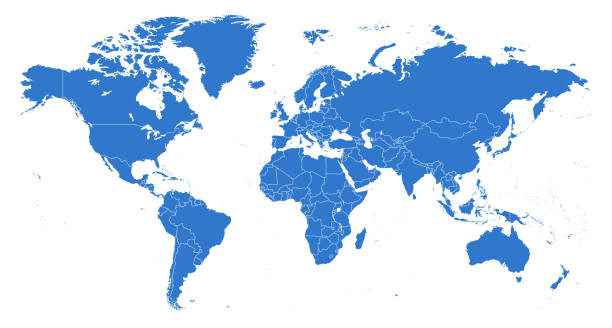

### **Factores:**

*- Tasa de alfabetización*

*- Migración neta*

*- Esperanza de vida*

*- Tasa de desempleo*

*- Crecimiento poblacional*

*- Crecimiento del PBI*

*- Educación secundaria*

*- Educación terciaria*

### **Hipótesis**

H: Todas las variables independientes seleccionadas tienen impacto en el promedio salarial.

### **Importancia del caso:**

*Las diferencias de inclusión laboral y de brecha de género entre hombres y mujeres están siendo un reto a nivel mundial. A pesar de que la fuerza de trabajo de la mujer ha aumentado en las últimas décadas, sigue estando 27 puntos porcentuales inferior a la de los hombres (OIT). La persistencia de las brechas de género en el mercado laboral representa una violación de los derechos económicos de las mujeres, que han sido reconocidos internacionalmente a través de compromisos en materia de derechos humanos e instrumentos específicos de derechos de la mujer (Convención sobre la eliminación de todas las formas de discriminación contra la mujer).*

*Las razones por las cuales este problema sigue perpetuándose se pueden explicar en base a distintos factores, por ejemplo, en primer lugar el acceso a la educación . A pesar de que el rendimiento de las mujeres son más altos para las mujeres solo en el caso de los percentiles 50 y 75 (por ejemplo, 2% para las mujeres y 1% para los hombres en ambos grupos), es decir, entre los individuos de mayor ingreso.*

*Otro factor, la residencia urbana del trabajador ejerce una influencia positiva sobre el ingreso medio, siendo el efecto similar para hombres y mujeres: por ejemplo, una mujer urbana gana un 44% más en comparación con una mujer con las mismas características pero que reside en el área rural, en el caso de los hombres urbanos, estos ganan un 64% más. El efecto de la educación disminuye a medida que nos movemos desde el percentil 10 al percentil 90.*

## **METODOLOGÍA Y DATOS**

[figure not shown]

## **ANÁLISIS EXPLORATORIO:**

*El análisis factorial exploratorio es una técnica estadística que se utiliza para identificar patrones y relaciones entre variables en un conjunto de datos. Su objetivo es reducir la complejidad de los datos al identificar las variables más importantes y agruparlas en factores latentes.* Esta técnica nos ha permitido identificar las variables que están más correlacionadas entre sí, lo que nos ayuda a entender mejor las relaciones entre ellas. Al agrupar estas variables en factores latentes, podemos reducir la cantidad de información que necesitamos procesar y obtener una visión más clara y concisa de los datos.

*Sin embargo, este análisis no nos da conclusiones. Por tanto, elegimos continuar con el siguiente modelo, para tener aproximaciones.*

## **MODELO DE REGRESIÓN LINEAL MÚLTIPLE:**

*El modelo de regresión lineal múltiple es una técnica estadística utilizada para analizar la relación entre una variable dependiente y dos o más variables independientes. En este modelo, se trata de ajustar una línea recta que mejor se ajuste a los datos, con el objetivo de predecir el valor de la variable dependiente en función de los valores de las variables independientes. En este caso, se está utilizando el modelo de regresión lineal múltiple para analizar si las variables independientes, que incluyen migración, tasa de alfabetización, PBI, crecimiento de la población, acceso a la electricidad, esperanza de vida, desempleo, educación secundaria, educación terciaria, empleo de mujeres y tasa de migración, son significativas en la variable dependiente, que en este caso es el salario.*

El objetivo de este análisis es determinar si existe una relación significativa entre las variables independientes y el salario, y si es así, identificar la fuerza y dirección de esta relación.

## **Fuentes**

Fuentes que utilizamos para la construcción de la base de datos

- Las bases de datos para las variables independientes provienen de diversos módulos de la data del Banco Mundial.
- La base de datos de la variable dependiente Promedio Salarial de un país, en adelante Promedio Salarial, ha sido proporcionado por el Banco Mundial.

## **Limpieza de la base de datos:**

- Se ha decidido trabajar sólo con los datos del año 2021 debido a que ese es el período más reciente con datos prácticamente completos para todas las variables.
- Para 2021, se tenía disponible el salario promedio de 126 países. Sin embargo, al combinarlo con otros módulos disponibles disponibles para el mismo año, se redujo a 101 casos completos.
- Para algunas bases de datos como Migración neta y Tasa de alfabetización se ha hecho el rename de los nombres de varios países de inglés a español con el comando *data[data$Pais==“Nombre original del pais”,‘Pais’]= “Nombre en español del país”* ya que al momento de descargar la base de datos, esta estaba en inglés.
- Para la limpieza de columnas se han utilizado los comandos *data[,c(2)]=NULL* y *data[,c(2:50)]=NULL*
- Para cambiar el nombre de las columnas se ha utilizado el comando *names(data)[1]<- ‘Pais’*
- Para eliminar filas se ha utilizado el comando *data <- filter(data, row_number() != 1)* debido a que en los diversos módulos del Banco Mundial, dentro de la columna países estaban incluídos diferentes organismos como “Union Europea”, “Países que forman parte de la OCDE”, entre otros que si bien incluyen a países de diversos bloques económicos, se decidió que no eran necesarios para el análisis.
- Los diferentes módulos de las bases de datos del Banco Mundial fueron unidas con la base de datos de Promedio Salarial usando el comando de *merge* de la siguiente forma *datafinal=merge(data1,data2)*
- Debido a que en algunos países se presentaban valores perdidos, el comando *merge* los fue eliminando de la Base de datos final por lo que sólo nos quedamos con 101 países.

## **JUSTIFICACIÓN DE LAS VARIABLES INDEPENDIENTES**

**DESEMPLEO:**

Esta variable tiene relevancia, ya que bajo distintos análisis económicos, el nivel de desempleo puede tener un impacto en los promedios salariales y viceversa ya que existen distintos factores que influyen por ejemplo, en primer lugar la oferta y demanda de trabajo. Cuando hay un alto nivel de desempleo, los empleadores pueden tener más poder de negociación para establecer salarios más bajos, ya que los trabajadores están dispuestos a aceptar empleos a cualquier precio para asegurar un ingreso. Esto puede conducir a una disminución en los promedios salariales. En segundo lugar, el crecimiento económico, ya que durante períodos de fuerte crecimiento económico, es posible que haya una mayor demanda de trabajadores, lo que puede generar una disminución del desempleo y un aumento en los promedios salariales. Esto se debe a que los empleadores pueden competir por trabajadores calificados, lo que les lleva a ofrecer salarios más altos para atraer y retener talento.En tercer lugar, las políticas gubernamentales, como el establecimiento de un salario mínimo o la implementación de políticas de protección laboral, pueden influir en los promedios salariales y en el desempleo. Por ejemplo, si se establece un salario mínimo alto, esto puede aumentar los costos laborales para los empleadores y potencialmente resultar en una disminución en la contratación o un aumento del desempleo. Por último, la productividad laboral: La productividad laboral, es decir, la cantidad de producción generada por cada trabajador, también puede influir en los promedios salariales y en el desempleo. Cuando los trabajadores son más productivos, es más probable que los empleadores estén dispuestos a pagar salarios más altos. Por otro lado, si la productividad laboral disminuye, esto puede tener un efecto negativo en los salarios y aumentar el desempleo.

**ESPERANZA DE VIDA:**

La variable “esperanza de vida” y la variación de promedios salariales en el mundo también están relacionadas, aunque es importante tener en cuenta que existen múltiples factores que pueden influir en cada una de estas variables. Por ejemplo esta se refiere al acceso a servicios de salud, condiciones de vida, estilos de vida y salud. A partir de estos factores se puede establecer una relación con el acceso a oportunidades laborales y , por tanto a mejores o peores condiciones de salarios. En primer lugar, el acceso a servicios de salud: Los salarios pueden influir en la esperanza de vida a través del acceso a servicios de salud de calidad. Los ingresos más altos permiten a las personas acceder a una atención médica adecuada, incluyendo visitas regulares al médico, medicamentos, tratamientos y cirugías necesarias. El acceso a servicios de salud de calidad puede ayudar a prevenir enfermedades, diagnosticarlas tempranamente y brindar tratamientos efectivos, lo que puede aumentar la esperanza de vida. En segundo lugar, las condiciones de vida: Los salarios más altos suelen estar asociados con mejores condiciones de vida, como viviendas de mejor calidad, acceso a agua potable, saneamiento básico, alimentación adecuada y entornos más seguros. Estas condiciones favorables pueden contribuir a una mejor salud y, por lo tanto, a una mayor esperanza de vida. En tercer lugar, el estilo de vida y salud, ya que los salarios también pueden influir en el estilo de vida de las personas. Un mayor ingreso puede permitir el acceso a opciones más saludables, como una alimentación balanceada, actividad física regular y tiempo para el descanso. Estas elecciones de estilo de vida saludables pueden tener un impacto positivo en la salud y contribuir a una mayor esperanza de vida.

**EDUCACIÓN SECUNDARIA:**

La variable “Educación Secundaria”, es importante porque impacta en los salarios de las personas, ya que puede limitar las opciones de carrera y los ingresos potenciales de una persona. Sin embargo, esto también puede variar según el país y el mercado laboral en el que se encuentre laborando. En primer lugar, tener una secundaria completa, genera mayor empleabilidad, pues es un requisito mínimo para muchos trabajos, lo que significa que las personas que han completado la educación secundaria tienen más oportunidades de empleo. Esto puede aumentar sus posibilidades de conseguir un trabajo remunerado al menos con el sueldo básico. En segundo lugar, mejora las habilidades pues proporciona a los estudiantes habilidades y conocimientos en áreas como matemáticas, ciencias, lenguaje y comunicación. Estas habilidades son valiosas en muchos trabajos y pueden ayudar a los empleados a ser más productivos y eficientes. Por último, el crecimiento profesional, debido a que puede ser un puente para continuar con la educación superior y el desarrollo profesional. Los trabajos que requieren educación superior suelen pagar más, y las personas con educación secundaria pueden estar mejor preparadas para seguir estudiando y avanzando una carrera. Esta variable mide el promedio de hombres y mujeres que tuvieron educación secundaria.

**EDUCACIÓN TERCIARIA:**

La variable “Educación Terciaria”, es importante porque tiene un impacto más significativo en el ingreso salarial promedio que tener solo educación secundaria. Esto se debe a que la educación terciaria proporciona habilidades y conocimientos especializados que son altamente valorados en el mercado laboral y que pueden resultar en trabajos mejor remunerados. En primer lugar, permite una mayor especialización, pues los estudiantes pueden especializarse en áreas específicas de estudio, lo que puede hacerlos más valiosos para los empleadores en campos específicos. Por ejemplo, en áreas como la medicina, la ingeniería o la tecnología, entre otros. En segundo lugar, el desarrollo de habilidades avanzadas debido a que proporciona habilidades avanzadas en áreas como el pensamiento crítico, la resolución de problemas y la toma de decisiones. Estas habilidades son altamente valoradas por los empleadores y pueden llevar a trabajos mejor remunerados en una variedad de campos. Asimismo, suelen tener más oportunidades de carrera y de ascenso profesional que aquellos con sólo educación secundaria. En tercer lugar, mayores oportunidades de carrera, ya que esto puede abrir puertas a una amplia gama de oportunidades de carrera que no están disponibles para aquellos con educación secundaria. Por ejemplo, los trabajos en áreas como la investigación científica o la gestión empresarial, entre otros. Asimismo, ofrecen salarios más altos que los trabajos que solo requieren educación secundaria. Esta variable mide el promedio de hombres y mujeres que tuvieron educación terciaria.

**EMPLEO DE MUJERES:**

La variable “Empleo de mujeres”, es importante porque refleja el grado de participación de las mujeres en la fuerza laboral y su capacidad para contribuir al crecimiento económico y al desarrollo de un país. Sin embargo, es importante considerar, que no necesariamente refleja la igualdad salarial, pues a mayor cantidad de mujeres empleadas, es menor el salario que la empresa invierte en ellas. En primero lugar, la equidad de género, es un tema importante debido a que las mujeres a menudo enfrentan discriminación salarial y de oportunidades en el lugar de trabajo, lo que puede afectar negativamente sus ingresos a lo largo del tiempo. Abogar por el empleo de las mujeres y apoyar la igualdad de oportunidades puede ayudar a reducir esta brecha salarial. En segundo lugar, la mejora de la economía pues tiene un impacto positivo en la economía en general. Las mujeres representan una gran parte de la fuerza laboral y su contribución es importante para el crecimiento económico lo cual permite mejorar la estabilidad económica de una empresa, y su impacto en la sociedad. En tercer lugar, la diversidad y perspectivas únicas pues al tener diferentes experiencias y habilidades, pueden contribuir de una mejor forma en el manejo de las funciones de una empresa y, por tanto, ayudaría en su crecimiento. Al contratar y promover el empleo de las mujeres, las empresas pueden beneficiarse de esta diversidad y mejorar su desempeño y rentabilidad a largo plazo. Esta variable mide el promedio de mujeres que son contratadas en las empresas.

**MIGRACIÓN NETA**

Es relevante estudiar la variable “migración” y su posible relación con el promedio salarial de un país debido a que los migrantes tienen efectos en la economía de su país de origen así como de país al cuál migran (por ejemplo, con las transacciones producidas por las remesas) así como poseen impacto en la dinámica del mercado laboral. Según el OIM (2021), para el año 2020, la cifra de migrantes a nivel mundial se había incrementado en 281 millones, una cifra elevada en comparación a años anteriores por lo que la migración es un tema relevante en el día a día en los países receptores. Estudiar esta variable es importante debido a que, dependiendo del contexto social, económico, cultural y político, la migración puede ser entendida como un problema o una oportunidad para mostrar el liderazgo político de un país receptor; un buen ejemplo para explicar esto es lo presentado por Wivel y Howard (2021), donde señalan que la migración puede ser enmarcada como un problema o un deber moral, dependiendo el contexto político, por ejemplo, políticas como Merkel enmarcaron la migración como una oportunidad de demostrar que Alemania, en conjunto con los países europeos, podían lidiar con esta crisis a través de políticas, en contraste, políticos como Donald Trump, enmarcaron a la migración como un problema que ocasionaba que “los verdaderos norteamericanos” se viesen desplazados por los migrantes ya que la migración retaba a aspectos como la seguridad y el bienestar financiero de todos los americanos por lo que era un “deber” detenerla; es así que al ser la migración un tema vigente y enmarcado de forma diferenciada en el debate público, se convierte en una intersante variable para el estudio. Según organismos como la CEPAL, la migración acarrea costos pero tambien beneficios economicos por lo que, al ser el promedio salarial una variable que está fuertemente relacionada con la economía de un páis, en el presente trabajo también se busca conocer si la migración tiene relación e impacto en el promedio salarial de un país.

**POBLACIÓN TOTAL**

Se busca conocer la incidencia de la población total, entendida como “todos los residentes independientemente de su estatus legal o ciudadanía” (Banco Mundial) de un país. Estudiar la relación entre el promedio salarial y la población total es importante para conocer más acerca de a economía de un país, el desarrollo económico, las políticas económicas entre otros ya que podría proporcionar informacion que aporte para explicar el promedio salarial de un país.

**PBI:**

El PBI es ampliamente utilizado como una medida de la actividad económica de un país. Representa el valor total de todos los bienes y servicios producidos en un período determinado. Al ser una medida integral de la actividad económica, el crecimiento del PBI se considera una indicación general del rendimiento económico de un país. Un mayor crecimiento económico, representado por un aumento en el PBI, generalmente se asocia con un aumento en la demanda de bienes y servicios (Cavallo & otros, 2021). Esto puede conducir a la creación de nuevos empleos y oportunidades laborales. A medida que se generan más empleos, existe la posibilidad de que la competencia por la mano de obra calificada aumente, lo que podría resultar en un aumento en los salarios. Asimismo, el crecimiento o disminución del PBI es una preocupación central para los formuladores de políticas económicas. Los gobiernos y las instituciones internacionales suelen establecer objetivos de crecimiento económico y adoptar medidas para fomentar el desarrollo económico (Cavallo & otros, 2021). Estas políticas pueden incluir incentivos para la inversión, el fomento de la innovación y la mejora de la infraestructura. Un mayor crecimiento económico a través de estas políticas puede tener un impacto positivo en el ingreso salarial promedio.

**CRECIMIENTO DE LA POBLACIÓN:**

Un mayor crecimiento de la población implica un aumento en la cantidad de personas en edad de trabajar. Como menciona la OIT (2012), esto puede resultar en una mayor oferta de mano de obra en el mercado laboral. A medida que aumenta la oferta de trabajadores, la competencia por los empleos puede intensificarse, lo que puede ejercer presión sobre los salarios. En un contexto de mayor oferta de trabajadores en relación con la demanda de empleo, es posible que los empleadores tengan más opciones y puedan ofrecer salarios más bajos. Además, con una mayor cantidad de personas buscando empleo, la competencia por los puestos de trabajo puede volverse más intensa. Los empleadores pueden aprovechar esta situación para negociar salarios más bajos, ya que tienen una amplia selección de candidatos para elegir. Esto puede afectar negativamente el ingreso salarial promedio, ya que los trabajadores pueden estar dispuestos a aceptar salarios más bajos para asegurar un empleo.

**ACCESO A LA ELECTRICIDAD:**

Como señalan Modi & Figueroa, el acceso a la electricidad es fundamental para impulsar la productividad y la eficiencia en diferentes sectores económicos. La electricidad proporciona energía para la maquinaria, equipos y tecnología utilizados en la producción y prestación de servicios. Un mayor acceso a la electricidad puede facilitar la automatización de procesos, mejorando la eficiencia y permitiendo un aumento en la producción. A medida que aumenta la productividad y la eficiencia, es posible generar mayores ingresos, lo que puede tener un impacto positivo en el salario promedio. El acceso a la electricidad está estrechamente vinculado al desarrollo económico de un país. Cuando más personas tienen acceso a la electricidad, se pueden desarrollar más actividades económicas y sectores industriales. Esto puede conducir a un crecimiento económico sostenido, con la creación de nuevos empleos y oportunidades laborales. A medida que la economía crece, es más probable que los salarios también aumenten, ya que hay una mayor demanda de trabajadores cualificados. Y es especialmente relevante en sectores clave como la industria, la agricultura y los servicios (Modi & Figueroa). Estos sectores pueden ser impulsados por la disponibilidad de energía eléctrica, lo que puede generar más empleos y aumentar los ingresos. Por ejemplo, en el sector agrícola, el acceso a la electricidad puede facilitar la irrigación, el procesamiento de alimentos y la conservación, lo que a su vez puede generar más empleo y aumentar los ingresos agrícolas.

## **PROCESO**

```r
library(rio)
DL = import("Bdfin.xlsx")
```

## **CAMBIO DE FORMATOS**

**VARIABLES INDEPENDIENTES**

```r
names(DL)
```

```
##  [1] "Pais"               "Migracion"          "Tasaalfabetizacion"
##  [4] "Poblaciont"         "PBI"                "Crecimientopob"
##  [7] "Electricidad"       "Esperanzavida"      "Desempleo"
## [10] "Educsecun"          "Educaterciaria"     "Emplmujer"
## [13] "Salario"
```

```r
DL$Migracion = as.numeric(DL$Migracion )
DL$Tasaalfabetizacion = as.numeric(DL$Tasaalfabetizacion)
DL$PBI = as.numeric(DL$PBI)
DL$Poblaciont = as.numeric(DL$Poblaciont)
DL$Esperanzavida = as.numeric(DL$Esperanzavida)
DL$Desempleo = as.numeric(DL$Desempleo)
DL$Educsecun = as.numeric(DL$Educsecun)
DL$Educaterciaria = as.numeric(DL$Educaterciaria)
DL$Crecimientopob = as.numeric(DL$Crecimientopob)
DL$Electricidad = as.numeric(DL$Electricidad)
```

```r
DL$TasaMigracion = DL$Migracion * 100000/DL$Poblaciont #Regla de tres simple
```

**VARIABLE DEPENDIENTE**

```r
DL$Salario = as.numeric(DL$Salario)
str(DL$Salario)
```

```
##  num [1:101] 710 1050 3393 2100 344 ...
```

```r
library(dplyr)
DG <- select(DL, -Pais, -Salario, -Poblaciont, -Migracion)
```

*se ha decidido crear una subdata DG porque no se utilizaran las variables Pais, (variable dependiente) Salario, Poblacion y Migracion.

## **ANÁLISIS FACTORIAL EXPLORATORIO**

*Se esta utilizando un analisis factorial explotario para resumir la informacion de nuestros grupos de variables a factores nuevos y obtener menor perdida de información. Asimismo nos permitira identificar que variables están mas correlacionadas.*

*Realizamos análisis factorial porque buscamos minimizar el riesgo de multicolinealidad, esto es, una alta correlación entre las variables independientes.*

## **Calcular la matriz de correlación**

```r
library(polycor)
corMatrix=polycor::hetcor(DG)$correlations
corMatrix
```

```
##                    Tasaalfabetizacion        PBI Crecimientopob Electricidad
## Tasaalfabetizacion          1.0000000  0.3272144    -0.65468372   0.74756155
## PBI                         0.3272144  1.0000000    -0.11987067   0.11384160
## Crecimientopob             -0.6546837 -0.1198707     1.00000000  -0.59305262
## Electricidad                0.7475616  0.1138416    -0.59305262   1.00000000
## Esperanzavida               0.7072292  0.1920281    -0.56987960   0.64899347
## Desempleo                   0.1284760  0.1933696    -0.04537261   0.11053471
## Educsecun                   0.3125782  0.3984609    -0.30431868   0.09699245
## Educaterciaria              0.1950955  0.2129453    -0.17802388   0.11278539
## Emplmujer                   0.6900593  0.1757910    -0.53005059   0.49004401
## TasaMigracion               0.1262875  0.2745966     0.17891962   0.06410197
##                    Esperanzavida   Desempleo   Educsecun Educaterciaria
## Tasaalfabetizacion    0.70722921  0.12847600  0.31257824     0.19509552
## PBI                   0.19202813  0.19336963  0.39846094     0.21294530
## Crecimientopob       -0.56987960 -0.04537261 -0.30431868    -0.17802388
## Electricidad          0.64899347  0.11053471  0.09699245     0.11278539
## Esperanzavida         1.00000000 -0.07709174  0.10537531     0.13879723
## Desempleo            -0.07709174  1.00000000  0.08059513    -0.03895168
## Educsecun             0.10537531  0.08059513  1.00000000     0.28944071
## Educaterciaria        0.13879723 -0.03895168  0.28944071     1.00000000
## Emplmujer             0.69876311  0.08887757  0.30740456     0.15594082
## TasaMigracion         0.30313271 -0.09555978 -0.12023354    -0.14926980
##                      Emplmujer TasaMigracion
## Tasaalfabetizacion  0.69005929    0.12628754
## PBI                 0.17579099    0.27459656
## Crecimientopob     -0.53005059    0.17891962
## Electricidad        0.49004401    0.06410197
## Esperanzavida       0.69876311    0.30313271
## Desempleo           0.08887757   -0.09555978
## Educsecun           0.30740456   -0.12023354
## Educaterciaria      0.15594082   -0.14926980
## Emplmujer           1.00000000    0.15251741
## TasaMigracion       0.15251741    1.00000000
```

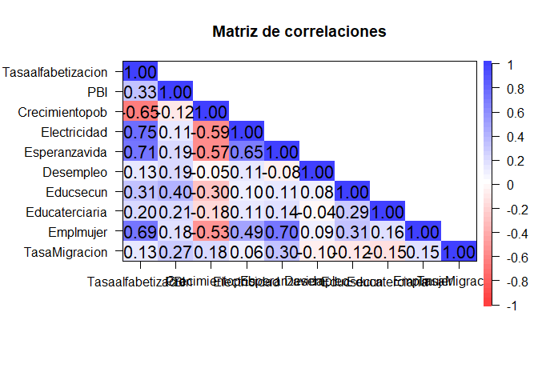

```r
library(psych)
cor.plot(corMatrix,
 numbers=T, #Se muestren los numeros de las correlaciones
upper=F, #Que aparezca la segunda parte
main= "Matriz de correlaciones",#Titulo
show.legend=T)#Mostrar leyenda
```

Se identifican correlaciones:

**ALTAS**

- Electricidad y tasa de alfabetización (0.75)
- Esperanza de vida y tasa de alfabetización (0.71)
- El % de empleados que son mujeres y la tasa de alfabetización (0.69)
- Electricidad y esperanza de vida (0.65)
- El % de empleados que son mujeres y esperanza de vida (0.70)

**INTERMEDIAS**

**BAJAS**

Finalmente, se encontró una correlación muy baja e, incluso, nula entre el desempleo y la mayoría de variables, a excepción del PBI (0.19) y la tasa de alfabetización (0.13). Por esta razón, se decide excluir el desempleo.

Además se encontró que se correlacionaba negativamente, por lo cual preferimos excluirla del modelo factorial, pero conservarla en la regresión.

```r
DG1 <- select(DG, -Desempleo, -TasaMigracion, -Crecimientopob)
```

*Volvemos a correr la matriz de correlaciones excluyendo el desempleo.*

```r
corMatrix1=polycor::hetcor(DG1)$correlations
corMatrix1
```

```
##                    Tasaalfabetizacion       PBI Electricidad Esperanzavida
## Tasaalfabetizacion          1.0000000 0.3272144   0.74756155     0.7072292
## PBI                         0.3272144 1.0000000   0.11384160     0.1920281
## Electricidad                0.7475616 0.1138416   1.00000000     0.6489935
## Esperanzavida               0.7072292 0.1920281   0.64899347     1.0000000
## Educsecun                   0.3125782 0.3984609   0.09699245     0.1053753
## Educaterciaria              0.1950955 0.2129453   0.11278539     0.1387972
## Emplmujer                   0.6900593 0.1757910   0.49004401     0.6987631
##                     Educsecun Educaterciaria Emplmujer
## Tasaalfabetizacion 0.31257824      0.1950955 0.6900593
## PBI                0.39846094      0.2129453 0.1757910
## Electricidad       0.09699245      0.1127854 0.4900440
## Esperanzavida      0.10537531      0.1387972 0.6987631
## Educsecun          1.00000000      0.2894407 0.3074046
## Educaterciaria     0.28944071      1.0000000 0.1559408
## Emplmujer          0.30740456      0.1559408 1.0000000
```

```r
cortest.bartlett(corMatrix,n=nrow(DG1))$p.value>0.05 #Menor a 0.05 saldrá FALSE, mayor a 0.05 saldra TRUE
```

```
## [1] FALSE
```

*- H0: la matriz de correlaciones es una matriz de identidad, o sea, las variables solo mantienen correlación consigo mismas.*

*- H0: la matriz de correlaciones NO es una matriz de identidad.*

- Conclusión: no es una matriz de identidad, por lo que podemos continuar con el AFE.

## **Evaluar adecuación de la muestra**

```r
library(psych)
psych::KMO(DG1)
```

```
## Kaiser-Meyer-Olkin factor adequacy
## Call: psych::KMO(r = DG1)
## Overall MSA =  0.73
## MSA for each item =
## Tasaalfabetizacion                PBI       Electricidad      Esperanzavida
##               0.75               0.63               0.72               0.79
##          Educsecun     Educaterciaria          Emplmujer
##               0.62               0.81               0.74
```

El KMO es 0.73, lo que es un valor bueno, lo cual posibilita seguir con el analisis.

## **Estimar el número de factores**

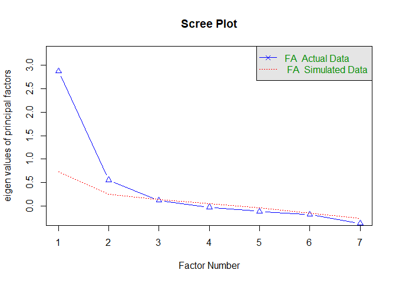

```
## Parallel analysis suggests that the number of factors =  2  and the number of components =  NA
```

```r
fa.parallel(corMatrix1, fm="pa", fa="fa", main = "Scree Plot")
```

El Scree Plot sugiere que el número de factores sea 2; sin embargo, el número de factores con eigen values por encima de 1 es 1.

```r
library(GPArotation)
factorial <- fa(DG1, nfactors= 2 ,rotate = "varimax", fm ="minres")
factorial
```

```
## Factor Analysis using method =  minres
## Call: fa(r = DG1, nfactors = 2, rotate = "varimax", fm = "minres")
## Standardized loadings (pattern matrix) based upon correlation matrix
##                     MR1  MR2   h2   u2 com
## Tasaalfabetizacion 0.86 0.34 0.86 0.14 1.3
## PBI                0.14 0.49 0.26 0.74 1.2
## Electricidad       0.77 0.05 0.60 0.40 1.0
## Esperanzavida      0.85 0.09 0.73 0.27 1.0
## Educsecun          0.06 0.80 0.65 0.35 1.0
## Educaterciaria     0.11 0.36 0.14 0.86 1.2
## Emplmujer          0.70 0.27 0.57 0.43 1.3
##
##                        MR1  MR2
## SS loadings           2.59 1.22
## Proportion Var        0.37 0.17
## Cumulative Var        0.37 0.54
## Proportion Explained  0.68 0.32
## Cumulative Proportion 0.68 1.00
##
## Mean item complexity =  1.1
## Test of the hypothesis that 2 factors are sufficient.
##
## df null model =  21  with the objective function =  3.04 with Chi Square =  294.7
## df of  the model are 8  and the objective function was  0.27
##
## The root mean square of the residuals (RMSR) is  0.04
## The df corrected root mean square of the residuals is  0.06
##
## The harmonic n.obs is  101 with the empirical chi square  5.65  with prob <  0.69
## The total n.obs was  101  with Likelihood Chi Square =  25.49  with prob <  0.0013
##
## Tucker Lewis Index of factoring reliability =  0.83
## RMSEA index =  0.147  and the 90 % confidence intervals are  0.086 0.214
## BIC =  -11.43
## Fit based upon off diagonal values = 0.99
## Measures of factor score adequacy
##                                                    MR1  MR2
## Correlation of (regression) scores with factors   0.95 0.84
## Multiple R square of scores with factors          0.90 0.71
## Minimum correlation of possible factor scores     0.80 0.43
```

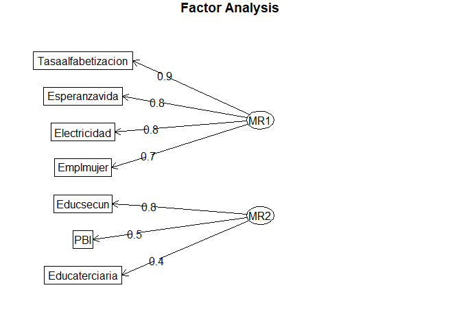

```r
fa.diagram(factorial)
```

El factor MR1 hace referencia a las condiciones de vida y el factor MR2 se refiere a oportunidades de crecimiento.

```r
print(factorial$loadings, cutoff = 0.35)
```

```
##
## Loadings:
##                    MR1   MR2
## Tasaalfabetizacion 0.862
## PBI                      0.494
## Electricidad       0.770
## Esperanzavida      0.850
## Educsecun                0.805
## Educaterciaria           0.356
## Emplmujer          0.702
##
##                  MR1   MR2
## SS loadings    2.586 1.219
## Proportion Var 0.369 0.174
## Cumulative Var 0.369 0.544
```

```r
sort(factorial$communality)
```

```
##     Educaterciaria                PBI          Emplmujer       Electricidad
##          0.1381590          0.2637467          0.5687917          0.5956668
##          Educsecun      Esperanzavida Tasaalfabetizacion
##          0.6515068          0.7312176          0.8557969
```

Variables se extrae la mayor cantidad de información: Alfabetización y, en segundo lugar, esperanza de vida.

```r
sort(factorial$complexity)
```

```
##       Electricidad          Educsecun      Esperanzavida                PBI
##           1.010074           1.012397           1.024439           1.161914
##     Educaterciaria Tasaalfabetizacion          Emplmujer
##           1.175000           1.297439           1.298403
```

```r
sort(factorial$uniquenesses)
```

```
## Tasaalfabetizacion      Esperanzavida          Educsecun       Electricidad
##          0.1442031          0.2687824          0.3484932          0.4043332
##          Emplmujer                PBI     Educaterciaria
##          0.4312083          0.7362533          0.8618410
```

Qué proporción de la varianza de la variable es varianza única.

```r
factorial_casos<-as.data.frame(factorial$scores)
head(factorial_casos)
```

```
##          MR1         MR2
## 1 -1.4213778 -4.42162949
## 2  0.2733029  0.43420984
## 3  0.8257325 -0.06508037
## 4  0.9722747 -2.50102829
## 5  0.3817295  0.57825978
## 6  0.1974364  0.37167672
```

```r
summary(factorial_casos)
```

```
##       MR1               MR2
##  Min.   :-3.1463   Min.   :-4.42163
##  1st Qu.:-0.5412   1st Qu.:-0.26820
##  Median : 0.2561   Median : 0.05374
##  Mean   : 0.0000   Mean   : 0.00000
##  3rd Qu.: 0.7301   3rd Qu.: 0.35414
##  Max.   : 1.0659   Max.   : 2.21713
```

```r
DL$factor1<- factorial_casos$MR1
DL$factor2<- factorial_casos$MR2
```

```r
library(BBmisc)
DL$factor1 = normalize(DL$factor1,
                                        method = "range",
                                        margin=2, # by column
                                        range = c(0, 100))
DL$factor2 = normalize(DL$factor2,
                                        method = "range",
                                        margin=2, # by column
                                        range = c(0, 100))
```

## **MODELO DE REGRESIÓN LINEAL MÚLTIPLE**

*JUSTIFICACIÓN*

Se esta utilizando una regresión lineal múltiple para ver si las variables independientes (migración, tasa de alfabetización, PBI, crecimiento de la población, acceso a la electricidad, esperanza de vida, desempleo, educación secundaria, educación terciaria, empleo de mujeres, tasa de migración) son signficativos en la variable dependiente (salario).

**Variable dependiente:** SALARIO

**Variable independiente:** MR1, MR2, Tasa de Migración, Desempleo, Crecimiento poblacional

```r
DL$MR1=DL$"Factor1"
DL$MR2=DL$"Factor2"
```

```r
library(tidyverse)
```

```r
modelo1= lm(Salario ~ factor1 + factor2, DL)
summary(modelo1)
```

```
##
## Call:
## lm(formula = Salario ~ factor1 + factor2, data = DL)
##
## Residuals:
##     Min      1Q  Median      3Q     Max
## -1707.6  -648.6  -156.5   448.4  4296.5
##
## Coefficients:
##             Estimate Std. Error t value Pr(>|t|)
## (Intercept) -693.375    587.063  -1.181    0.240
## factor1       30.988      4.362   7.103 1.96e-10 ***
## factor2        1.986      7.714   0.257    0.797
## ---
## Signif. codes:  0 '***' 0.001 '**' 0.01 '*' 0.05 '.' 0.1 ' ' 1
##
## Residual standard error: 976 on 98 degrees of freedom
## Multiple R-squared:  0.3443, Adjusted R-squared:  0.3309
## F-statistic: 25.73 on 2 and 98 DF,  p-value: 1.041e-09
```

*Se propuso un primer modelo en el que solo se incluyó los factores extraídos por el EFA. Dicho modelo:*

**Dicho modelo:** - Es significativo, con un p valor de 1.041e-09.

- Tiene un R cudrado de 0.3309, lo que significa que el 33% de la varianza de la variable dependiente es explicada por el modelo
- Se identificó efecto significativo del factor 1, este efecto es positivo.

```r
modelo2= lm(Salario ~ factor1 + TasaMigracion + Desempleo + Crecimientopob, DL)
summary(modelo2)
```

```
##
## Call:
## lm(formula = Salario ~ factor1 + TasaMigracion + Desempleo +
##     Crecimientopob, data = DL)
##
## Residuals:
##     Min      1Q  Median      3Q     Max
## -1622.7  -582.2  -226.4   469.4  3120.7
##
## Coefficients:
##                 Estimate Std. Error t value Pr(>|t|)
## (Intercept)     586.6459   530.3072   1.106  0.27139
## factor1          19.6786     6.1595   3.195  0.00189 **
## TasaMigracion     0.4783     0.2424   1.973  0.05141 .
## Desempleo       -21.1945    19.9865  -1.060  0.29161
## Crecimientopob -242.9920   100.5824  -2.416  0.01759 *
## ---
## Signif. codes:  0 '***' 0.001 '**' 0.01 '*' 0.05 '.' 0.1 ' ' 1
##
## Residual standard error: 945.9 on 96 degrees of freedom
## Multiple R-squared:  0.3967, Adjusted R-squared:  0.3716
## F-statistic: 15.78 on 4 and 96 DF,  p-value: 5.838e-10
```

```r
library(lm.beta)
modelo1$coefficients
```

```
## (Intercept)     factor1     factor2
## -693.374866   30.987819    1.985813
```